# R Notebook

# Prep

## Library Prep

```r
library(tidyverse)
```

```r
library(ggplot2)
library(rstatix)
```

## Data Import

```r
# Set the file path
file_path <- "BRFSS-subset.csv"

# Read the CSV file into a data frame
brfss_data <- read.csv(file_path, header = TRUE, stringsAsFactors = FALSE, sep = ";")

# Look at the data briefly
head(brfss_data)
```

|  | Age | Weight | Sex | Height | Year |
| --- | --- | --- | --- | --- | --- |
| 1 | 31 | 48.98798 | Female | 157.48 | 1990 |
| 2 | 57 | 81.64663 | Female | 157.48 | 1990 |
| 3 | 43 | 80.28585 | Male | 177.80 | 1990 |
| 4 | 72 | 70.30682 | Male | 170.18 | 1990 |
| 5 | 31 | 49.89516 | Female | 154.94 | 1990 |
| 6 | 58 | 54.43108 | Female | 154.94 | 1990 |

```r
dim(brfss_data)
```

```
## [1] 20000     5
```

# Exercise

## Part 1 - Descriptive Statistics

### Height Distribution

Let’s look at how the height distribution in our dataset. Is the pattern is as we expected ? What would we expect ?

This is a continuous data - so one can use either a histogram or a smooth density plot for this.

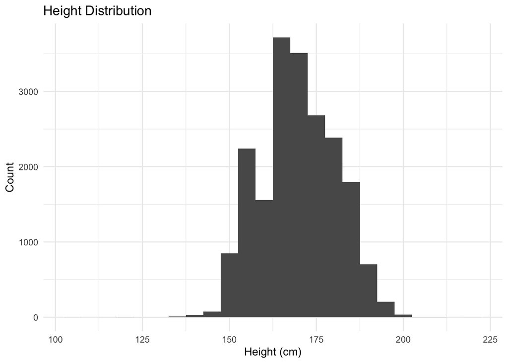

```r
ggplot(brfss_data, aes(x = Height))+
  geom_histogram(binwidth = 5) +
  labs(title = "Height Distribution",
       x = "Height (cm)",
       y = "Count") +
  theme_minimal()
```

Now lets calculate the mean, and the SD values for this data and see how much of the people’s heights are within the 1 and 2 SD of the data.

```r
# Compute mean and standard deviation
mean_height <- mean(brfss_data$Height, na.rm = TRUE) # Mean
sd_height <- sd(brfss_data$Height, na.rm = TRUE) # Standard Deviation

# Define ranges for 1 SD and 2 SD
one_sd_range <- c(mean_height - sd_height, mean_height + sd_height)
two_sd_range <- c(mean_height - 2 * sd_height, mean_height + 2 * sd_height)

# Calculate the percentage of people within each range
within_1sd <- sum(brfss_data$Height >= one_sd_range[1] & brfss_data$Height <= one_sd_range[2], na.rm = TRUE) / nrow(brfss_data) * 100
within_2sd <- sum(brfss_data$Height >= two_sd_range[1] & brfss_data$Height <= two_sd_range[2], na.rm = TRUE) / nrow(brfss_data) * 100

# Create a table
height_stats <- data.frame(
  Metric = c("Mean Height", "1 SD Range", "2 SD Range", "% within 1 SD", "% within 2 SD"),
  Value = c(
    round(mean_height, 2),
    paste(round(one_sd_range[1], 2), "-", round(one_sd_range[2], 2)),
    paste(round(two_sd_range[1], 2), "-", round(two_sd_range[2], 2)),
    paste(round(within_1sd, 2), "%"),
    paste(round(within_2sd, 2), "%")
  )
)

height_stats
```

| Metric | Value |
| --- | --- |
| Mean Height | 169.21 |
| 1 SD Range | 158.97 - 179.46 |
| 2 SD Range | 148.73 - 189.7 |
| % within 1 SD | 63.85 % |
| % within 2 SD | 95.98 % |

Now let’s add these lines into our plot.

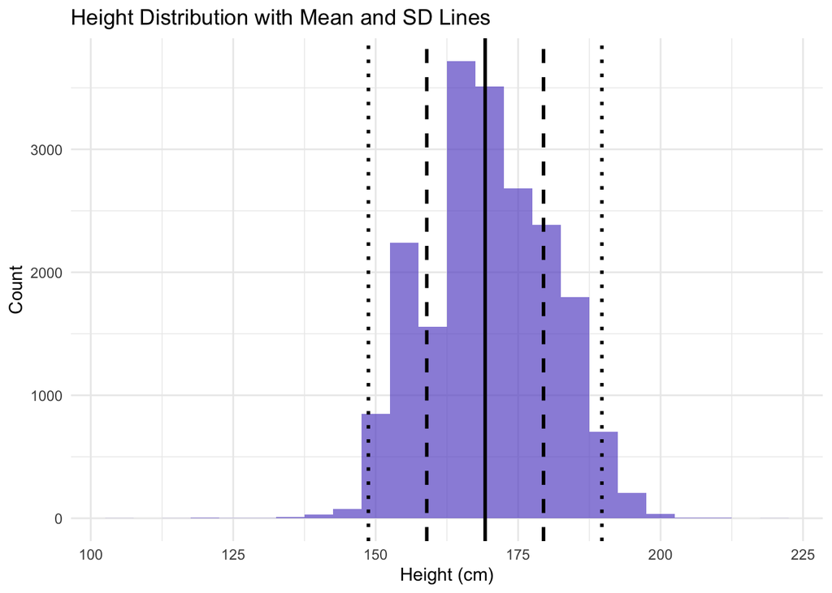

```r
# Create the histogram with mean and SD lines
ggplot(brfss_data, aes(x = Height)) +
  geom_histogram(binwidth = 5, fill = "slateblue", alpha = 0.7) +
  geom_vline(aes(xintercept = mean_height), linetype = "solid", size = 1) +
  geom_vline(aes(xintercept = one_sd_range[1]), linetype = "dashed", size = 1) +
  geom_vline(aes(xintercept = one_sd_range[2]), linetype = "dashed", size = 1) +
  geom_vline(aes(xintercept = two_sd_range[1]), linetype = "dotted", size = 1) +
  geom_vline(aes(xintercept = two_sd_range[2]), linetype = "dotted", size = 1) +
  labs(title = "Height Distribution with Mean and SD Lines",
       x = "Height (cm)",
       y = "Count") +
  theme_minimal()
```

### Height Distribution - Sex

Could sex be a factor in height difference amongst people ? Let’s look at their contribituon to our distribution plot.

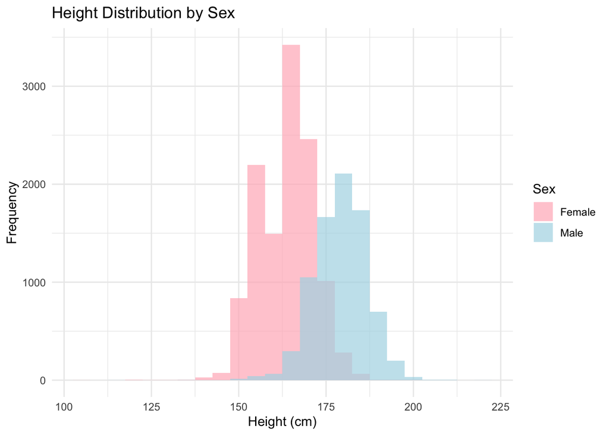

```r
# Create a combined histogram with color differentiation for Sex
ggplot(brfss_data, aes(x = Height, fill = Sex)) +
  geom_histogram(binwidth = 5, alpha = 0.7, position = "identity") +
  labs(title = "Height Distribution by Sex",
       x = "Height (cm)",
       y = "Frequency") +
  theme_minimal() +
  scale_fill_manual(values = c("Female" = "lightpink", "Male" = "lightblue"))
```

Okay it seems like females and males have diffferent mean and SD than one anoher. So let’s calculate those stats for each sex seperately.

```r
# Compute mean and standard deviation for each sex

# For Females
female_data <- subset(brfss_data, Sex == "Female")
mean_female_height <- mean(female_data$Height, na.rm = TRUE)
sd_female_height <- sd(female_data$Height, na.rm = TRUE)

# For Males
male_data <- subset(brfss_data, Sex == "Male")
mean_male_height <- mean(male_data$Height, na.rm = TRUE)
sd_male_height <- sd(male_data$Height, na.rm = TRUE)

# Define ranges for 1 SD and 2 SD for Females
female_one_sd_range <- c(mean_female_height - sd_female_height, mean_female_height + sd_female_height)
female_two_sd_range <- c(mean_female_height - 2 * sd_female_height, mean_female_height + 2 * sd_female_height)

# Define ranges for 1 SD and 2 SD for Males
male_one_sd_range <- c(mean_male_height - sd_male_height, mean_male_height + sd_male_height)
male_two_sd_range <- c(mean_male_height - 2 * sd_male_height, mean_male_height + 2 * sd_male_height)

# Calculate the percentage of people within each range (1 SD and 2 SD) for Females
female_within_1sd <- sum(female_data$Height >= female_one_sd_range[1] & female_data$Height <= female_one_sd_range[2], na.rm = TRUE) / nrow(female_data) * 100
female_within_2sd <- sum(female_data$Height >= female_two_sd_range[1] & female_data$Height <= female_two_sd_range[2], na.rm = TRUE) / nrow(female_data) * 100

# Calculate the percentage of people within each range (1 SD and 2 SD) for Males
male_within_1sd <- sum(male_data$Height >= male_one_sd_range[1] & male_data$Height <= male_one_sd_range[2], na.rm = TRUE) / nrow(male_data) * 100
male_within_2sd <- sum(male_data$Height >= male_two_sd_range[1] & male_data$Height <= male_two_sd_range[2], na.rm = TRUE) / nrow(male_data) * 100

# Create a table for Females, Males and not subsetted data
height_stats_sexes <- data.frame(
  Metric = c("Mean Height", "1 SD Range", "2 SD Range", "% within 1 SD", "% within 2 SD"),
  Female = c(
    round(mean_female_height, 2),
    paste(round(female_one_sd_range[1], 2), "-", round(female_one_sd_range[2], 2)),
    paste(round(female_two_sd_range[1], 2), "-", round(female_two_sd_range[2], 2)),
    paste(round(female_within_1sd, 2), "%"),
    paste(round(female_within_2sd, 2), "%")
  ),
  Male = c(
    round(mean_male_height, 2),
    paste(round(male_one_sd_range[1], 2), "-", round(male_one_sd_range[2], 2)),
    paste(round(male_two_sd_range[1], 2), "-", round(male_two_sd_range[2], 2)),
    paste(round(male_within_1sd, 2), "%"),
    paste(round(male_within_2sd, 2), "%")
  ),
  All = c(
    round(mean_height, 2),
    paste(round(one_sd_range[1], 2), "-", round(one_sd_range[2], 2)),
    paste(round(two_sd_range[1], 2), "-", round(two_sd_range[2], 2)),
    paste(round(within_1sd, 2), "%"),
    paste(round(within_2sd, 2), "%")
  )
)

height_stats_sexes
```

| Metric | Female | Male | All |
| --- | --- | --- | --- |
| Mean Height | 163.29 | 178.11 | 169.21 |
| 1 SD Range | 156.25 - 170.33 | 170.61 - 185.62 | 158.97 - 179.46 |
| 2 SD Range | 149.21 - 177.37 | 163.1 - 193.12 | 148.73 - 189.7 |
| % within 1 SD | 74.03 % | 69.2 % | 63.85 % |
| % within 2 SD | 94.89 % | 95.49 % | 95.98 % |

Now lets create the plots.

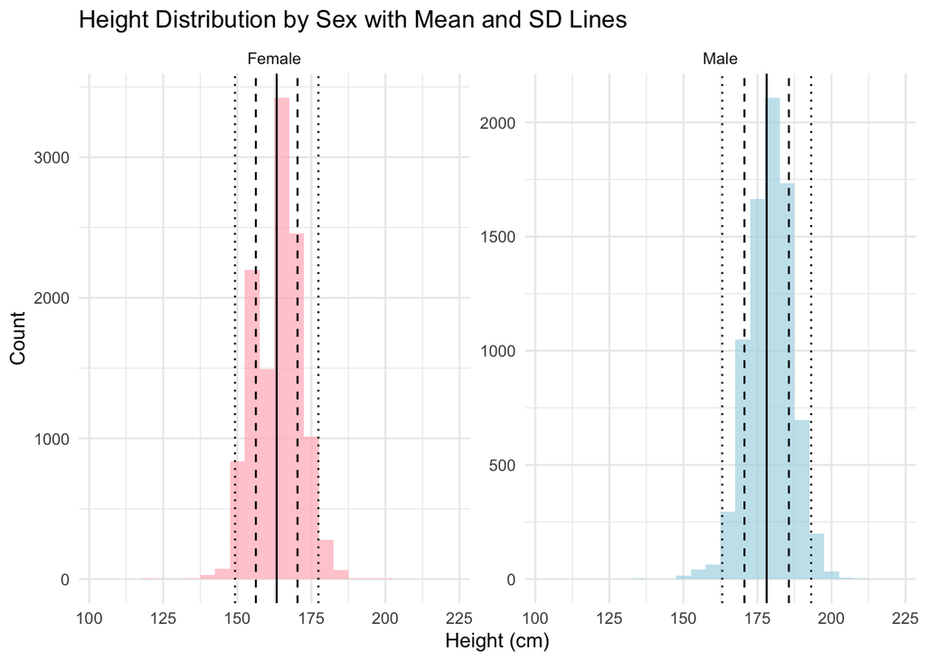

```r
# Create histograms with SD lines for each sex using pre-computed stats

ggplot(brfss_data, aes(x = Height, fill = Sex)) +
  geom_histogram(binwidth = 5, alpha = 0.7, position = "identity") +
  facet_wrap(~ Sex, scales = "free_y") +
  scale_fill_manual(values = c("Female" = "lightpink", "Male" = "lightblue"))+
  theme(legend.position = "none") +

  # Female SD Lines (only on Female plot)
  geom_vline(data = subset(brfss_data, Sex == "Female"),
             aes(xintercept = mean_female_height), linetype = "solid", size = 0.5) +  # Mean line for females
  geom_vline(data = subset(brfss_data, Sex == "Female"),
             aes(xintercept = female_one_sd_range[1]), linetype = "dashed", size = 0.5) +  # 1 SD min line for females
  geom_vline(data = subset(brfss_data, Sex == "Female"),
             aes(xintercept = female_one_sd_range[2]), linetype = "dashed", size = 0.5) +  # 1 SD max line for females
  geom_vline(data = subset(brfss_data, Sex == "Female"),
             aes(xintercept = female_two_sd_range[1]), linetype = "dotted", size = 0.5) +  # 2 SD min line for females
  geom_vline(data = subset(brfss_data, Sex == "Female"),
             aes(xintercept = female_two_sd_range[2]), linetype = "dotted", size = 0.5) +  # 2 SD max line for females

  # Male SD Lines (only on Male plot)
  geom_vline(data = subset(brfss_data, Sex == "Male"),
             aes(xintercept = mean_male_height), linetype = "solid", size = 0.5) +  # Mean line for males
  geom_vline(data = subset(brfss_data, Sex == "Male"),
             aes(xintercept = male_one_sd_range[1]), linetype = "dashed", size = 0.5) +  # 1 SD min line for males
  geom_vline(data = subset(brfss_data, Sex == "Male"),
             aes(xintercept = male_one_sd_range[2]), linetype = "dashed", size = 0.5) +  # 1 SD max line for males
  geom_vline(data = subset(brfss_data, Sex == "Male"),
             aes(xintercept = male_two_sd_range[1]), linetype = "dotted", size = 0.5) +  # 2 SD min line for males
  geom_vline(data = subset(brfss_data, Sex == "Male"),
             aes(xintercept = male_two_sd_range[2]), linetype = "dotted", size = 0.5) +  # 2 SD max line for males

  labs(title = "Height Distribution by Sex with Mean and SD Lines",
       x = "Height (cm)",
       y = "Count") +
  theme_minimal() +
  theme(legend.position = "none")
```

## Part 2 - Inferential Statistics

```r
brfss_data %>% nrow()
```

```
## [1] 20000
```

### Sampling

```r
# Set seed for reproducibility and sample 10, 100, and 1000 rows
brfs_sub10 <- brfss_data %>% sample_n(10)
set.seed(2024)
brfs_sub100 <- brfss_data %>% sample_n(100)
set.seed(2024)
brfs_sub1000 <- brfss_data %>% sample_n(1000)
set.seed(2024)
brfs_sub10000 <- brfss_data %>% sample_n(10000)

# View the first few rows of each sample
head(brfs_sub10)
```

|  | Age | Weight | Sex | Height | Year |
| --- | --- | --- | --- | --- | --- |
| 1 | 83 | 63.50293 | Female | 150.00 | 2010 |
| 2 | 74 | 88.45051 | Male | 180.00 | 2010 |
| 3 | 28 | 43.09128 | Female | 160.02 | 1990 |
| 4 | 56 | 58.05982 | Female | 173.00 | 2010 |
| 5 | 36 | 61.23497 | Female | 170.18 | 1990 |
| 6 | 25 | 124.28431 | Female | 162.56 | 1990 |

```r
head(brfs_sub100)
```

|  | Age | Weight | Sex | Height | Year |
| --- | --- | --- | --- | --- | --- |
| 1 | 50 | 113.39809 | Male | 178.0 | 2010 |
| 2 | 66 | 54.43108 | Male | 175.0 | 2010 |
| 3 | 29 | 60.78138 | Female | 160.0 | 2010 |
| 4 | 38 | 61.68856 | Female | 173.0 | 2010 |
| 5 | 42 | 86.18255 | Male | 177.8 | 1990 |
| 6 | 87 | 61.23497 | Female | 157.0 | 2010 |

```r
head(brfs_sub1000)
```

|  | Age | Weight | Sex | Height | Year |
| --- | --- | --- | --- | --- | --- |
| 1 | 50 | 113.39809 | Male | 178.0 | 2010 |
| 2 | 66 | 54.43108 | Male | 175.0 | 2010 |
| 3 | 29 | 60.78138 | Female | 160.0 | 2010 |
| 4 | 38 | 61.68856 | Female | 173.0 | 2010 |
| 5 | 42 | 86.18255 | Male | 177.8 | 1990 |
| 6 | 87 | 61.23497 | Female | 157.0 | 2010 |

```r
head(brfs_sub10000)
```

|  | Age | Weight | Sex | Height | Year |
| --- | --- | --- | --- | --- | --- |
| 1 | 50 | 113.39809 | Male | 178.0 | 2010 |
| 2 | 66 | 54.43108 | Male | 175.0 | 2010 |
| 3 | 29 | 60.78138 | Female | 160.0 | 2010 |
| 4 | 38 | 61.68856 | Female | 173.0 | 2010 |
| 5 | 42 | 86.18255 | Male | 177.8 | 1990 |
| 6 | 87 | 61.23497 | Female | 157.0 | 2010 |

Without setting seed, sampling would give us different results everytime.

```r
#set.seed(2024)
brfss_data %>% sample_n(10)
```

| Age | Weight | Sex | Height | Year |
| --- | --- | --- | --- | --- |
| 51 | 73.48196 | Female | 167.64 | 1990 |
| 68 | 90.71847 | Male | 180.34 | 1990 |
| 58 | 87.08974 | Female | 160.00 | 2010 |
| 60 | 124.73790 | Male | 188.00 | 2010 |
| 24 | 90.71847 | Female | 172.72 | 1990 |
| 59 | 61.23497 | Male | 168.00 | 2010 |
| 90 | 63.50293 | Female | 160.00 | 2010 |
| 44 | 99.79032 | Male | 180.00 | 2010 |
| 32 | 95.25440 | Male | 198.12 | 1990 |
| 71 | 52.16312 | Female | 162.56 | 1990 |

### Distribution and Mean of the Height

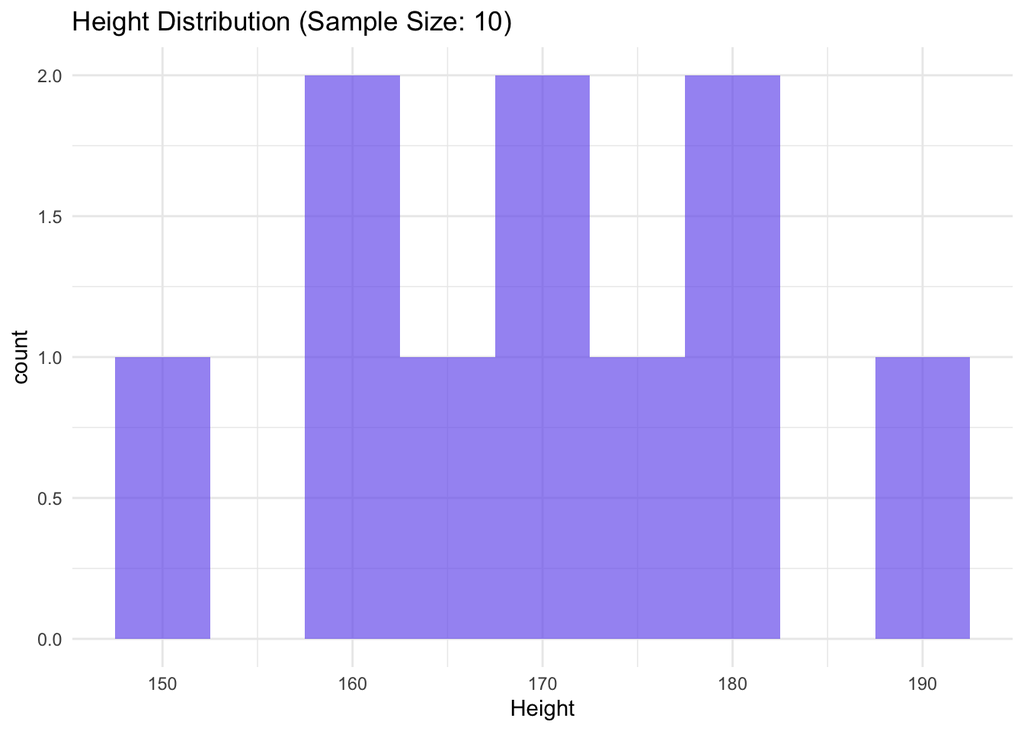

```r
# For brfs_sub10
ggplot(brfs_sub10, aes(x = Height, fill = Sex)) +
  geom_histogram(binwidth = 5, fill = 'slateblue2', alpha = 0.7) +
  theme_minimal() +
  labs(title = "Height Distribution (Sample Size: 10)")
```

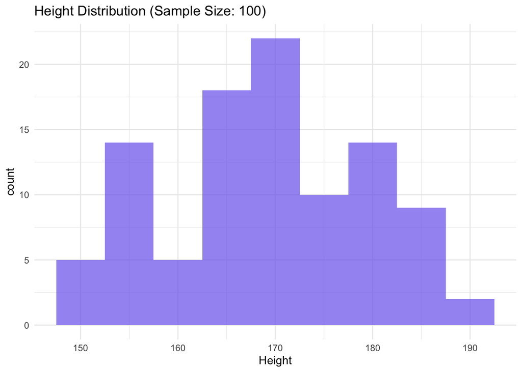

```r
# For brfs_sub100
ggplot(brfs_sub100, aes(x = Height, fill = Sex)) +
  geom_histogram(binwidth = 5, fill = 'slateblue2', alpha = 0.7) +
  theme_minimal() +
  labs(title = "Height Distribution (Sample Size: 100)")
```

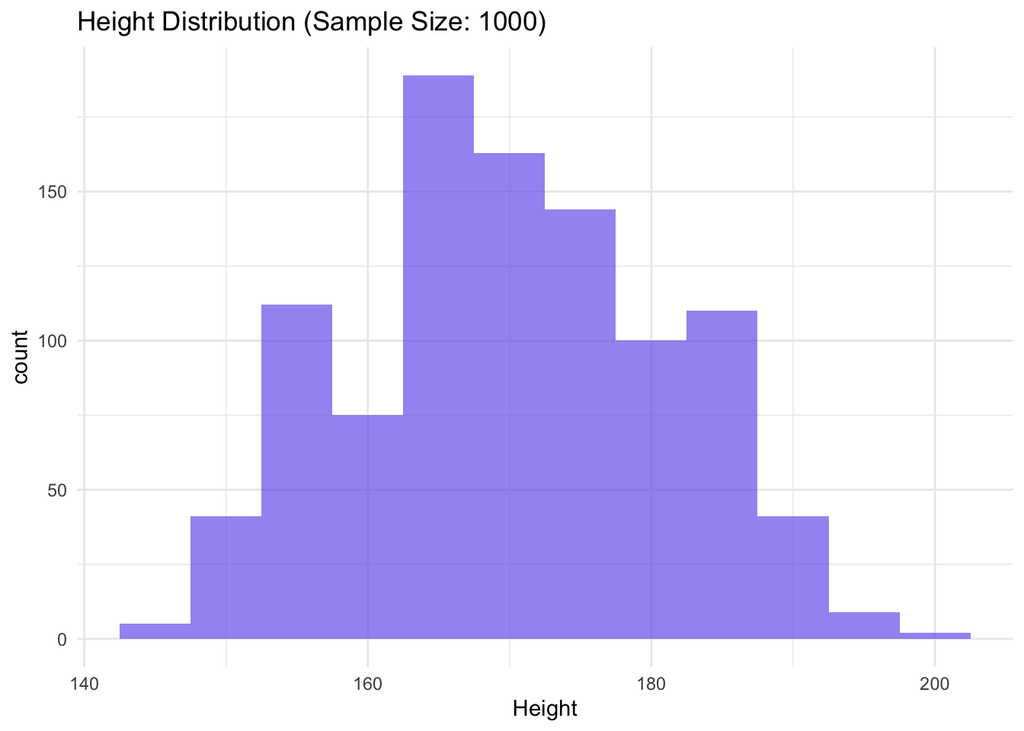

```r
# For brfs_sub1000
ggplot(brfs_sub1000, aes(x = Height, fill = Sex)) +
  geom_histogram(binwidth = 5, fill = 'slateblue2', alpha = 0.7) +
  theme_minimal() +
  labs(title = "Height Distribution (Sample Size: 1000)")
```

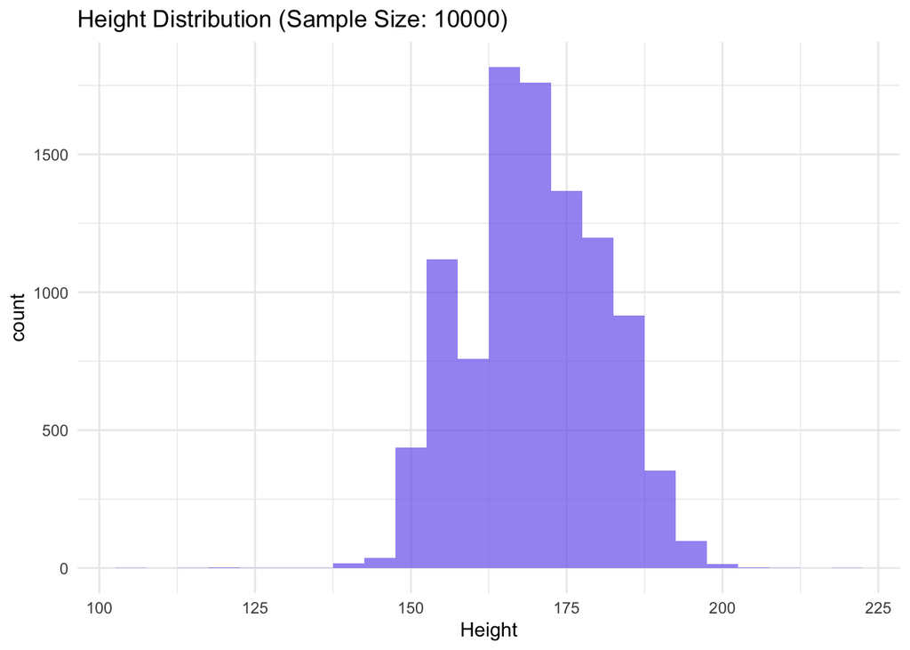

```r
# For brfs_sub10000
ggplot(brfs_sub10000, aes(x = Height, fill = Sex)) +
  geom_histogram(binwidth = 5, fill = 'slateblue2', alpha = 0.7) +
  theme_minimal() +
  labs(title = "Height Distribution (Sample Size: 10000)")
```

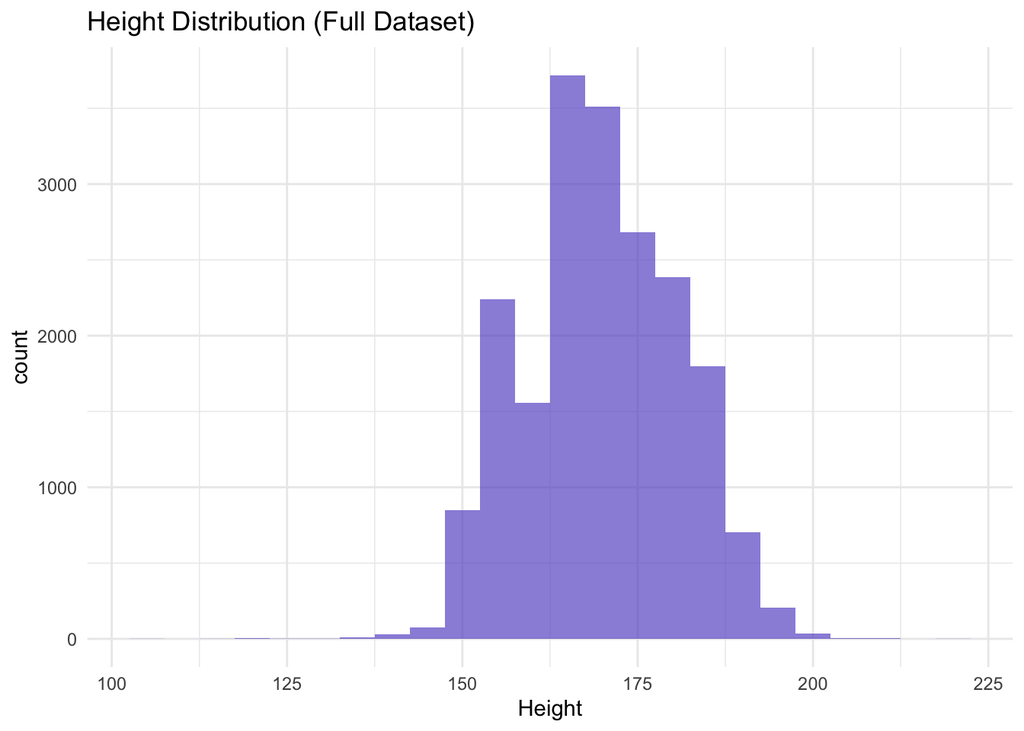

```r
# For brfss_data
ggplot(brfss_data, aes(x = Height, fill = Sex)) +
  geom_histogram(binwidth = 5, fill = 'slateblue', alpha = 0.7) +
  theme_minimal() +
  labs(title = "Height Distribution (Full Dataset)")
```

Now let’s see how confident we are with calculating mean from this data.

```r
t.test(brfs_sub10$Height, conf.level = 0.90)
```

```
##
##  One Sample t-test
##
## data:  brfs_sub10$Height
## t = 46.59, df = 9, p-value = 4.841e-12
## alternative hypothesis: true mean is not equal to 0
## 90 percent confidence interval:
##  162.7405 176.0715
## sample estimates:
## mean of x
##   169.406
```

```r
t.test(brfs_sub10$Height, conf.level = 0.95)
```

```
##
##  One Sample t-test
##
## data:  brfs_sub10$Height
## t = 46.59, df = 9, p-value = 4.841e-12
## alternative hypothesis: true mean is not equal to 0
## 95 percent confidence interval:
##  161.1805 177.6315
## sample estimates:
## mean of x
##   169.406
```

```r
t.test(brfs_sub10$Height, conf.level = 0.99)
```

```
##
##  One Sample t-test
##
## data:  brfs_sub10$Height
## t = 46.59, df = 9, p-value = 4.841e-12
## alternative hypothesis: true mean is not equal to 0
## 99 percent confidence interval:
##  157.5891 181.2229
## sample estimates:
## mean of x
##   169.406
```

### Height ~ Sex

Run t_test with different sample sizes.

```r
brfs_sub10000 %>%
  t_test(Height ~ Sex, conf.level = 0.95, detailed = TRUE)
```

|  | estimate | estimate1 | estimate2 | .y. | group1 | group2 | n1 | n2 | statistic | p | df | conf.low | conf.high | method | alternative |
| --- | --- | --- | --- | --- | --- | --- | --- | --- | --- | --- | --- | --- | --- | --- | --- |
| 1 | -14.68785 | 163.3497 | 178.0376 | Height | Female | Male | 5918 | 3988 | -97.01423 | 0 | 8225.392 | -14.98463 | -14.39107 | T-test | two.sided |

```r
brfs_sub1000 %>%
  t_test(Height ~ Sex, conf.level = 0.95, detailed = TRUE)
```

|  | estimate | estimate1 | estimate2 | .y. | group1 | group2 | n1 | n2 | statistic | p | df | conf.low | conf.high | method | alternative |
| --- | --- | --- | --- | --- | --- | --- | --- | --- | --- | --- | --- | --- | --- | --- | --- |
| 1 | -14.77107 | 163.3939 | 178.165 | Height | Female | Male | 580 | 411 | -30.98907 | 2.72e-140 | 822.0015 | -15.70667 | -13.83546 | T-test | two.sided |

```r
brfs_sub100 %>%
  t_test(Height ~ Sex, conf.level = 0.95, detailed = TRUE)
```

|  | estimate | estimate1 | estimate2 | .y. | group1 | group2 | n1 | n2 | statistic | p | df | conf.low | conf.high | method | alternative |
| --- | --- | --- | --- | --- | --- | --- | --- | --- | --- | --- | --- | --- | --- | --- | --- |
| 1 | -12.87191 | 162.9222 | 175.7941 | Height | Female | Male | 55 | 44 | -8.906105 | 5.92e-14 | 88.90962 | -15.74371 | -10.00011 | T-test | two.sided |

```r
brfs_sub10 %>%
  t_test(Height ~ Sex, conf.level = 0.95, detailed = TRUE)
```

|  | estimate | estimate1 | estimate2 | .y. | group1 | group2 | n1 | n2 | statistic | p | df | conf.low | conf.high | method | alternative |
| --- | --- | --- | --- | --- | --- | --- | --- | --- | --- | --- | --- | --- | --- | --- | --- |
| 1 | -16.94833 | 162.6267 | 179.575 | Height | Female | Male | 6 | 4 | -3.40176 | 0.0112 | 7.108983 | -28.69291 | -5.203758 | T-test | two.sided |